# Diabetes Prediction using Health Indicators

ST563 Presentation 1: Logistic Regression and KNN

Data: cleaned 2021 BRFSS (Kaggle), 236,378 respondents, 21 health indicators. Positive class of binary tasks = 1 (prediabetes or diabetes), negative = 0 (no diabetes). Kaggle’s binary file codes prediabetes as 0, so the imbalanced binary outcome is derived from the 3-class file. The balanced file is used as is.

# Data

```r
data.012=read.csv("data/diabetes_012_health_indicators_BRFSS2021.csv")
data.bal=read.csv("data/diabetes_binary_5050split_health_indicators_BRFSS2021.csv")
dim(data.012)
```

```
## [1] 236378     22
```

```r
dim(data.bal)
```

```
## [1] 67136    22
```

```r
# 3-class outcome and binary outcome (1 = prediab or diab)
table(data.012$Diabetes_012)
```

```
##
##      0      1      2
## 197191   5619  33568
```

```r
data.012$y.bin=as.numeric(data.012$Diabetes_012>0)
data.012$y.cls=factor(data.012$Diabetes_012)
table(data.012$y.bin)
```

```
##
##      0      1
## 197191  39187
```

```r
table(data.bal$Diabetes_binary)
```

```
##
##     0     1
## 33568 33568
```

```r
xvars=names(data.012)[-c(1,23,24)]   # 21 predictors
length(xvars)
```

```
## [1] 21
```

# Train / test split

Stratified 80/20 split (fixed seed), same rows used for the imbalanced and 3-class tasks.

```r
set.seed(42)
idx=createDataPartition(data.bal$Diabetes_binary,p=0.8,list=FALSE)
bal.tr=data.bal[idx,]
bal.te=data.bal[-idx,]

set.seed(42)
idx=createDataPartition(data.012$y.bin,p=0.8,list=FALSE)
imb.tr=data.012[idx,]
imb.te=data.012[-idx,]
cls.tr=data.012[idx,]
cls.te=data.012[-idx,]

cat("balanced:",nrow(bal.tr),"/",nrow(bal.te),"\n")
```

```
## balanced: 53710 / 13426
```

```r
cat("imbalanced:",nrow(imb.tr),"/",nrow(imb.te),"\n")
```

```
## imbalanced: 189103 / 47275
```

```r
cat("3-class:",nrow(cls.tr),"/",nrow(cls.te),"\n")
```

```
## 3-class: 189103 / 47275
```

```r
metric.bin=function(truth,pred,prob){
  tp=sum(truth==1&pred==1); fp=sum(truth==0&pred==1)
  fn=sum(truth==1&pred==0); tn=sum(truth==0&pred==0)
  acc=(tp+tn)/length(truth)
  precision=tp/(tp+fp)
  recall=tp/(tp+fn)
  specificity=tn/(tn+fp)
  f1=2*precision*recall/(precision+recall)
  auc=as.numeric(roc(truth,prob,levels=c(0,1),direction="<",quiet=TRUE)$auc)
  c(accuracy=acc,precision=precision,recall=recall,specificity=specificity,f1=f1,auc=auc)
}

metric.cls=function(truth,pred){
  per=NULL
  for(cl in 0:2){
    tp=sum(truth==cl&pred==cl); fp=sum(truth!=cl&pred==cl); fn=sum(truth==cl&pred!=cl)
    prec=ifelse(tp+fp==0,0,tp/(tp+fp))
    rec=ifelse(tp+fn==0,0,tp/(tp+fn))
    f1=ifelse(prec+rec==0,0,2*prec*rec/(prec+rec))
    per=rbind(per,data.frame(class=cl,precision=prec,recall=rec,f1=f1))
  }
  list(accuracy=mean(truth==pred),per_class=per,macro_f1=mean(per$f1))
}
```

# Logistic regression

## Binary (balanced and imbalanced)

```r
fit.lr.bal=glm(Diabetes_binary~.,data=bal.tr[,c("Diabetes_binary",xvars)],family=binomial)
fit.lr.imb=glm(y.bin~.,data=imb.tr[,c("y.bin",xvars)],family=binomial)

p.lr.bal=predict(fit.lr.bal,bal.te,type="response")
p.lr.imb=predict(fit.lr.imb,imb.te,type="response")
```

```r
m.bal.lr=metric.bin(bal.te$Diabetes_binary,as.numeric(p.lr.bal>0.5),p.lr.bal)
m.imb.lr=metric.bin(imb.te$y.bin,as.numeric(p.lr.imb>0.5),p.lr.imb)
data.frame(LR.balanced=round(m.bal.lr,4),LR.imbalanced=round(m.imb.lr,4))
```

|  | LR.balanced | LR.imbalanced |
| --- | --- | --- |
| accuracy | 0.7418 | 0.8433 |
| precision | 0.7318 | 0.5651 |
| recall | 0.7633 | 0.1860 |
| specificity | 0.7202 | 0.9720 |
| f1 | 0.7472 | 0.2799 |
| auc | 0.8152 | 0.8055 |

```r
table(pred=as.numeric(p.lr.bal>0.5),truth=bal.te$Diabetes_binary)
```

```
##     truth
## pred    0    1
##    0 4835 1589
##    1 1878 5124
```

```r
table(pred=as.numeric(p.lr.imb>0.5),truth=imb.te$y.bin)
```

```
##     truth
## pred     0     1
##    0 38427  6300
##    1  1108  1440
```

## Coefficients and odds ratios (imbalanced model, 189,103 training rows)

```r
est=coef(fit.lr.imb)
se=summary(fit.lr.imb)$coefficients[,"Std. Error"]
tab.or=round(cbind(OR=exp(est),lower=exp(est-1.96*se),upper=exp(est+1.96*se)),3)
z=est/se
tab.or=tab.or[order(abs(z),decreasing=TRUE),]
tab.or=tab.or[rownames(tab.or)!="(Intercept)",]
tab.or
```

```
##                         OR lower upper
## BMI                  1.064 1.062 1.066
## GenHlth              1.585 1.558 1.613
## HighBP               1.930 1.873 1.989
## Age                  1.125 1.119 1.131
## HighChol             1.799 1.749 1.850
## CholCheck            4.073 3.498 4.743
## HvyAlcoholConsump    0.513 0.477 0.552
## Sex                  1.286 1.250 1.323
## Income               0.943 0.936 0.949
## HeartDiseaseorAttack 1.281 1.231 1.333
## PhysActivity         0.857 0.830 0.884
## PhysHlth             0.994 0.992 0.996
## Stroke               1.174 1.110 1.241
## Education            0.961 0.946 0.975
## DiffWalk             1.086 1.047 1.127
## MentHlth             0.996 0.994 0.998
## Smoker               0.943 0.917 0.970
## NoDocbcCost          1.091 1.030 1.155
## Fruits               0.969 0.942 0.997
## Veggies              0.972 0.939 1.007
## AnyHealthcare        1.048 0.963 1.142
```

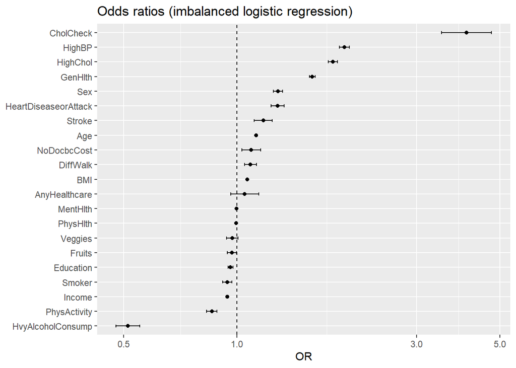

```r
or.plot=data.frame(var=rownames(tab.or),OR=tab.or[,"OR"],lo=tab.or[,"lower"],hi=tab.or[,"upper"])
ggplot(or.plot,aes(x=reorder(var,OR),y=OR))+
  geom_point()+geom_errorbar(aes(ymin=lo,ymax=hi),width=0.2)+
  geom_hline(yintercept=1,lty=2)+scale_y_log10()+
  coord_flip()+labs(x=NULL,title="Odds ratios (imbalanced logistic regression)")
```

Predictive associations only, not causal. Largest |z|: BMI, GenHlth, HighBP, Age, HighChol.

## 3-class (multinomial logistic regression)

```r
fit.mn=multinom(y.cls~.,data=cls.tr[,c("y.cls",xvars)],maxit=300,trace=FALSE)
p.mn=predict(fit.mn,cls.te,type="probs")                # columns = "0","1","2"
pred.mn=as.numeric(colnames(p.mn)[apply(p.mn,1,which.max)])
truth.cls=cls.te$Diabetes_012
cat("convergence:",fit.mn$convergence,"\n")
```

```
## convergence: 0
```

```r
met.mn=metric.cls(truth.cls,pred.mn)
met.mn$per_class
```

| class | precision | recall | f1 |
| --- | --- | --- | --- |
| 0 | 0.8561449 | 0.9765271 | 0.9123823 |
| 1 | 0.0000000 | 0.0000000 | 0.0000000 |
| 2 | 0.5318661 | 0.1745411 | 0.2628300 |

```r
cat("accuracy:",round(met.mn$accuracy,4),"macro F1:",round(met.mn$macro_f1,4),"\n")
```

```
## accuracy: 0.8412 macro F1: 0.3917
```

```r
# one-vs-rest AUC per class
for(cl in 0:2){
  yb=as.numeric(truth.cls==cl)
  cat("OVR AUC class",cl,":",round(as.numeric(roc(yb,p.mn[,cl+1],levels=c(0,1),direction="<",quiet=TRUE)$auc),3),"\n")
}
```

```
## OVR AUC class 0 : 0.805
## OVR AUC class 1 : 0.677
## OVR AUC class 2 : 0.816
```

```r
table(pred=pred.mn,truth=truth.cls)
```

```
##     truth
## pred     0     1     2
##    0 38607  1001  5486
##    2   928    93  1160
```

```r
# true share vs predicted share (argmax rule)
true.share=prop.table(table(factor(truth.cls,levels=0:2)))
pred.share=prop.table(table(factor(pred.mn,levels=0:2)))
data.frame(class=0:2,true.share=round(as.numeric(true.share),3),
           predicted.share=round(as.numeric(pred.share),3))
```

| class | true.share | predicted.share |
| --- | --- | --- |
| 0 | 0.836 | 0.954 |
| 1 | 0.023 | 0.000 |
| 2 | 0.141 | 0.046 |

```r
# coefficients (log-odds vs class 0)
coef.mn=coef(fit.mn)
round(t(rbind(prediabetes=coef.mn["1",],diabetes=coef.mn["2",])),3)
```

```
##                      prediabetes diabetes
## (Intercept)               -6.935   -7.848
## HighBP                     0.302    0.731
## HighChol                   0.602    0.587
## CholCheck                  0.933    1.565
## BMI                        0.056    0.063
## Smoker                    -0.063   -0.058
## Stroke                    -0.059    0.187
## HeartDiseaseorAttack       0.002    0.276
## PhysActivity               0.028   -0.185
## Fruits                    -0.049   -0.029
## Veggies                    0.010   -0.036
## HvyAlcoholConsump         -0.354   -0.739
## AnyHealthcare             -0.188    0.114
## NoDocbcCost                0.227    0.060
## GenHlth                    0.274    0.497
## MentHlth                   0.004   -0.005
## PhysHlth                  -0.009   -0.006
## DiffWalk                   0.035    0.088
## Sex                        0.107    0.280
## Age                        0.089    0.124
## Education                 -0.079   -0.034
## Income                    -0.075   -0.056
```

Accuracy ~84% equals the majority class share (83.4%). Under the argmax rule nearly all rows are labeled “0”: prediabetes (2.4%) is never the most probable class, and diabetes is under-predicted. This is class imbalance plus overlap of the classes, not a fitting error - the OVR AUC above shows the ranking ability.

# KNN

Binary tasks (positive = 1). Predictors standardised with training mean/sd only. k is chosen by 5-fold CV on the training set. For the imbalanced task CV uses a 40,000-row training subsample to save time (test set untouched), the final model uses the full training set.

```r
stand=function(d.tr,d.te){
  X.tr=as.matrix(d.tr[,xvars]); X.te=as.matrix(d.te[,xvars])
  mu=colMeans(X.tr); s=apply(X.tr,2,sd); s[s==0]=1
  list(tr=scale(X.tr,center=mu,scale=s),te=scale(X.te,center=mu,scale=s))
}
ks=c(1,3,5,7,9,13,17,21,25,31,41,61,81,101)

knn.cv=function(X,y){
  set.seed(42)
  folds=createFolds(as.factor(y),k=5)
  res=NULL
  for(i in 1:5){
    vi=folds[[i]]; tri=setdiff(1:nrow(X),vi)
    nn=get.knnx(X[tri,,drop=FALSE],X[vi,,drop=FALSE],k=max(ks))
    ytr=y[tri]; yv=y[vi]
    for(k in ks){
      pr=rowMeans(matrix(ytr[nn$nn.index[,1:k,drop=FALSE]],ncol=k))
      acc=mean((pr>0.5)==yv)
      auc=as.numeric(roc(yv,pr,levels=c(0,1),direction="<",quiet=TRUE)$auc)
      res=rbind(res,data.frame(k=k,acc=acc,auc=auc))
    }
  }
  aggregate(cbind(acc,auc)~k,res,mean)
}
```

```r
X.bal=stand(bal.tr,bal.te)
cv.bal=knn.cv(X.bal$tr,bal.tr$Diabetes_binary)

set.seed(42)
sub.imb=sample(nrow(imb.tr),40000)
X.imb=stand(imb.tr,imb.te)
cv.imb=knn.cv(X.imb$tr[sub.imb,,drop=FALSE],imb.tr$y.bin[sub.imb])
```

```r
k.best.bal=cv.bal$k[which.max(cv.bal$auc)]
k.best.imb=cv.imb$k[which.max(cv.imb$auc)]
cat("chosen k, balanced:",k.best.bal,"(CV AUC",round(max(cv.bal$auc),4),")\n")
```

```
## chosen k, balanced: 101 (CV AUC 0.8087 )
```

```r
cat("chosen k, imbalanced:",k.best.imb,"(CV AUC",round(max(cv.imb$auc),4),")\n")
```

```
## chosen k, imbalanced: 101 (CV AUC 0.7895 )
```

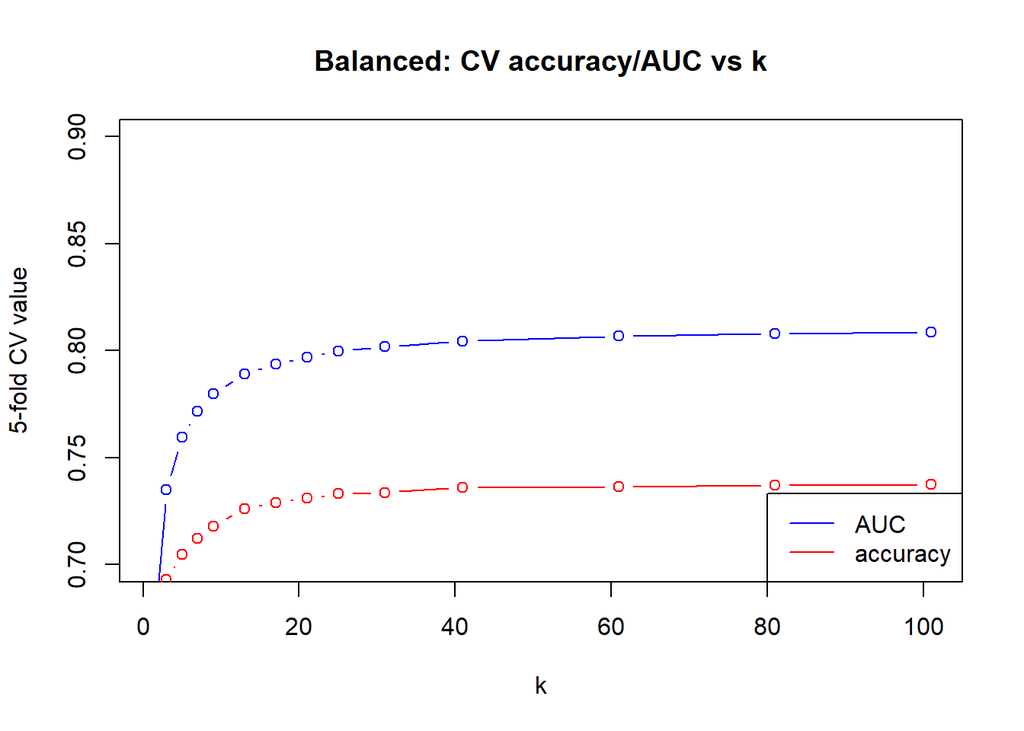

```r
plot(cv.bal$k,cv.bal$auc,type="b",col="blue",ylab="5-fold CV value",xlab="k",
     main="Balanced: CV accuracy/AUC vs k",ylim=c(0.7,0.9))
lines(cv.bal$k,cv.bal$acc,type="b",col="red")
legend("bottomright",legend=c("AUC","accuracy"),col=c("blue","red"),lty=1)
```

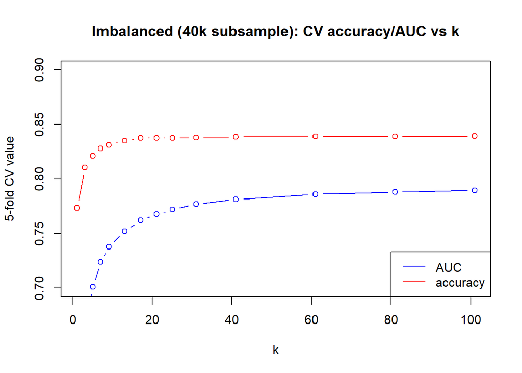

```r
plot(cv.imb$k,cv.imb$auc,type="b",col="blue",ylab="5-fold CV value",xlab="k",
     main="Imbalanced (40k subsample): CV accuracy/AUC vs k",ylim=c(0.7,0.9))
lines(cv.imb$k,cv.imb$acc,type="b",col="red")
legend("bottomright",legend=c("AUC","accuracy"),col=c("blue","red"),lty=1)
```

```r
knn.prob=function(X.tr,y.tr,X.te,k){
  nn=get.knnx(X.tr,X.te,k=k)
  rowMeans(matrix(y.tr[nn$nn.index],ncol=k))
}
p.knn.bal=knn.prob(X.bal$tr,bal.tr$Diabetes_binary,X.bal$te,k.best.bal)
p.knn.imb=knn.prob(X.imb$tr,imb.tr$y.bin,X.imb$te,k.best.imb)

m.bal.knn=metric.bin(bal.te$Diabetes_binary,as.numeric(p.knn.bal>0.5),p.knn.bal)
m.imb.knn=metric.bin(imb.te$y.bin,as.numeric(p.knn.imb>0.5),p.knn.imb)
data.frame(KNN.balanced=round(m.bal.knn,4),KNN.imbalanced=round(m.imb.knn,4))
```

|  | KNN.balanced | KNN.imbalanced |
| --- | --- | --- |
| accuracy | 0.7361 | 0.8430 |
| precision | 0.7156 | 0.6056 |
| recall | 0.7837 | 0.1171 |
| specificity | 0.6885 | 0.9851 |
| f1 | 0.7481 | 0.1962 |
| auc | 0.8089 | 0.7989 |

```r
table(pred=as.numeric(p.knn.bal>0.5),truth=bal.te$Diabetes_binary)
```

```
##     truth
## pred    0    1
##    0 4622 1452
##    1 2091 5261
```

```r
table(pred=as.numeric(p.knn.imb>0.5),truth=imb.te$y.bin)
```

```
##     truth
## pred     0     1
##    0 38945  6834
##    1   590   906
```

## 3-class KNN (majority vote)

Same preprocessing. k chosen by 5-fold CV (accuracy) on a 40,000-row training subsample; final model uses the full training set.

```r
ks3=c(31,61,101,151,201)
knn3.cv=function(X,y){
  set.seed(42)
  folds=createFolds(as.factor(y),k=5)
  res=NULL
  for(i in 1:5){
    vi=folds[[i]]; tri=setdiff(1:nrow(X),vi)
    nn=get.knnx(X[tri,,drop=FALSE],X[vi,,drop=FALSE],k=max(ks3))
    ytr=y[tri]; yv=y[vi]
    for(k in ks3){
      nb=matrix(ytr[nn$nn.index[,1:k,drop=FALSE]],ncol=k)
      votes=cbind(rowSums(nb==0),rowSums(nb==1),rowSums(nb==2))
      pred=apply(votes,1,which.max)-1
      res=rbind(res,data.frame(k=k,acc=mean(pred==yv)))
    }
  }
  aggregate(acc~k,res,mean)
}

X.cls=stand(cls.tr,cls.te)
set.seed(42)
sub.cls=sample(nrow(cls.tr),40000)
cv.cls=knn3.cv(X.cls$tr[sub.cls,,drop=FALSE],cls.tr$Diabetes_012[sub.cls])
cv.cls
```

| k | acc |
| --- | --- |
| 31 | 0.837425 |
| 61 | 0.837500 |
| 101 | 0.837775 |
| 151 | 0.837725 |
| 201 | 0.837875 |

```r
k.best.cls=cv.cls$k[which.max(cv.cls$acc)]
cat("chosen k, 3-class:",k.best.cls,"(CV accuracy",round(max(cv.cls$acc),4),")\n")
```

```
## chosen k, 3-class: 201 (CV accuracy 0.8379 )
```

```r
nn3=get.knnx(X.cls$tr,X.cls$te,k=k.best.cls)
nb=matrix(cls.tr$Diabetes_012[nn3$nn.index],ncol=k.best.cls)
votes=cbind(rowSums(nb==0),rowSums(nb==1),rowSums(nb==2))
pred.knn3=apply(votes,1,which.max)-1

met.knn3=metric.cls(truth.cls,pred.knn3)
met.knn3$per_class
```

| class | precision | recall | f1 |
| --- | --- | --- | --- |
| 0 | 0.8450601 | 0.99218414 | 0.9127314 |
| 1 | 0.0000000 | 0.00000000 | 0.0000000 |
| 2 | 0.5985998 | 0.07718929 | 0.1367453 |

```r
cat("accuracy:",round(met.knn3$accuracy,4),"macro F1:",round(met.knn3$macro_f1,4),"\n")
```

```
## accuracy: 0.8406 macro F1: 0.3498
```

```r
p.knn3=votes/k.best.cls
for(cl in 0:2){
  yb=as.numeric(truth.cls==cl)
  cat("OVR AUC class",cl,":",round(as.numeric(roc(yb,p.knn3[,cl+1],levels=c(0,1),direction="<",quiet=TRUE)$auc),3),"\n")
}
```

```
## OVR AUC class 0 : 0.801
## OVR AUC class 1 : 0.645
## OVR AUC class 2 : 0.81
```

```r
table(pred=pred.knn3,truth=truth.cls)
```

```
##     truth
## pred     0     1     2
##    0 39226  1059  6133
##    2   309    35   513
```

```r
prop.table(table(pred.knn3))
```

```
## pred.knn3
##          0          2
## 0.98187203 0.01812797
```

Same result as multinomial logistic: accuracy ~84% is the majority-class baseline, prediab is never the majority vote in a neighborhood.

# Model comparison

Binary (test sets, positive = 1):

```r
eval.bin=data.frame(
  LR.balanced=round(m.bal.lr,3),LR.imbalanced=round(m.imb.lr,3),
  KNN.balanced=round(m.bal.knn,3),KNN.imbalanced=round(m.imb.knn,3))
t(eval.bin)
```

```
##                accuracy precision recall specificity    f1   auc
## LR.balanced       0.742     0.732  0.763       0.720 0.747 0.815
## LR.imbalanced     0.843     0.565  0.186       0.972 0.280 0.806
## KNN.balanced      0.736     0.716  0.784       0.689 0.748 0.809
## KNN.imbalanced    0.843     0.606  0.117       0.985 0.196 0.799
```

```r
# majority baseline (always predict 0)
base.bal=mean(bal.te$Diabetes_binary==0)
base.imb=mean(imb.te$y.bin==0)
data.frame(dataset=c("balanced","imbalanced"),
           majority.accuracy=c(round(base.bal,3),round(base.imb,3)))
```

| dataset | majority.accuracy |
| --- | --- |
| balanced | 0.500 |
| imbalanced | 0.836 |

3-class (test set):

```r
data.frame(
  model=c("multinomial LR","KNN"),
  accuracy=round(c(met.mn$accuracy,met.knn3$accuracy),4),
  macro_F1=round(c(met.mn$macro_f1,met.knn3$macro_f1),4))
```

| model | accuracy | macro_F1 |
| --- | --- | --- |
| multinomial LR | 0.8412 | 0.3917 |
| KNN | 0.8406 | 0.3498 |

# ROC curves

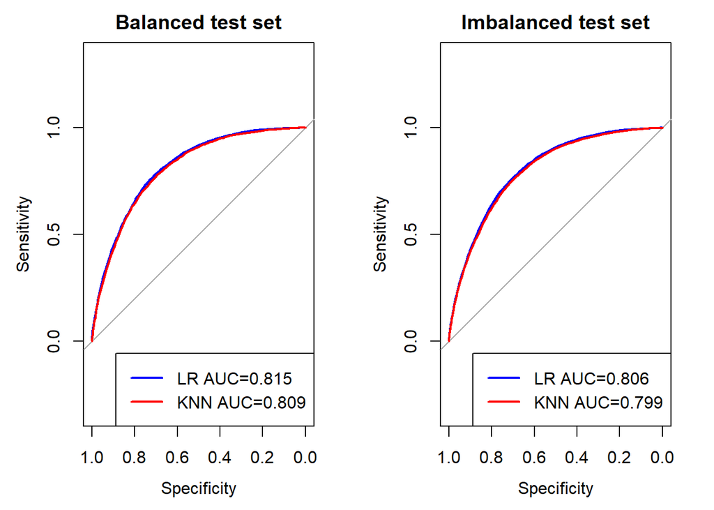

```r
roc.bal.lr=roc(bal.te$Diabetes_binary,p.lr.bal,levels=c(0,1),direction="<",quiet=TRUE)
roc.bal.knn=roc(bal.te$Diabetes_binary,p.knn.bal,levels=c(0,1),direction="<",quiet=TRUE)
roc.imb.lr=roc(imb.te$y.bin,p.lr.imb,levels=c(0,1),direction="<",quiet=TRUE)
roc.imb.knn=roc(imb.te$y.bin,p.knn.imb,levels=c(0,1),direction="<",quiet=TRUE)

par(mfrow=c(1,2))
plot(roc.bal.lr,col="blue",lwd=2,main="Balanced test set")
lines(roc.bal.knn,col="red",lwd=2)
legend("bottomright",col=c("blue","red"),lwd=2,
       legend=c(paste0("LR AUC=",round(auc(roc.bal.lr),3)),
                paste0("KNN AUC=",round(auc(roc.bal.knn),3))))
plot(roc.imb.lr,col="blue",lwd=2,main="Imbalanced test set")
lines(roc.imb.knn,col="red",lwd=2)
legend("bottomright",col=c("blue","red"),lwd=2,
       legend=c(paste0("LR AUC=",round(auc(roc.imb.lr),3)),
                paste0("KNN AUC=",round(auc(roc.imb.knn),3))))
```

```r
par(mfrow=c(1,1))
```

# Summary of figures and results

Figures/tables produced above:

1. class counts and imbalance ratios (Data)
2. train/test sizes (Train / test split)
3. LR test metrics, balanced and imbalanced (Logistic regression)
4. LR confusion matrices (test sets)
5. LR coefficients / odds-ratio table and plot (imbalanced)
6. multinomial LR per-class metrics, OVR AUC, confusion matrix
7. multinomial coefficients
8. KNN CV accuracy/AUC vs k plots, chosen k
9. KNN test metrics and confusion matrices
10. 3-class KNN CV accuracy vs k, test metrics, confusion matrix
11. binary model comparison table + majority baseline
12. 3-class model comparison table
13. ROC curves with AUC (both binary tasks)

Key numbers:

```r
cat("binary test AUC - LR:",round(m.bal.lr["auc"],3),"(balanced),",
    round(m.imb.lr["auc"],3),"(imbalanced); KNN:",round(m.bal.knn["auc"],3),
    "(balanced),",round(m.imb.knn["auc"],3),"(imbalanced)\n")
```

```
## binary test AUC - LR: 0.815 (balanced), 0.806 (imbalanced); KNN: 0.809 (balanced), 0.799 (imbalanced)
```

```r
cat("binary test recall - LR:",round(m.bal.lr["recall"],3),"(balanced),",
    round(m.imb.lr["recall"],3),"(imbalanced); KNN:",round(m.bal.knn["recall"],3),
    "(balanced),",round(m.imb.knn["recall"],3),"(imbalanced)\n")
```

```
## binary test recall - LR: 0.763 (balanced), 0.186 (imbalanced); KNN: 0.784 (balanced), 0.117 (imbalanced)
```

```r
cat("majority-class accuracy on imbalanced test set:",round(base.imb,3),"\n")
```

```
## majority-class accuracy on imbalanced test set: 0.836
```

```r
cat("chosen k - balanced:",k.best.bal,", imbalanced:",k.best.imb,
    ", 3-class:",k.best.cls,"\n")
```

```
## chosen k - balanced: 101 , imbalanced: 101 , 3-class: 201
```

```r
cat("3-class multinomial LR - accuracy:",round(met.mn$accuracy,4),
    ", macro F1:",round(met.mn$macro_f1,3),
    ", prediab recall:",round(met.mn$per_class$recall[2],3),
    ", diab recall:",round(met.mn$per_class$recall[3],3),"\n")
```

```
## 3-class multinomial LR - accuracy: 0.8412 , macro F1: 0.392 , prediab recall: 0 , diab recall: 0.175
```

```r
cat("3-class KNN - accuracy:",round(met.knn3$accuracy,4),
    ", macro F1:",round(met.knn3$macro_f1,3),
    ", prediab recall:",round(met.knn3$per_class$recall[2],3),
    ", diab recall:",round(met.knn3$per_class$recall[3],3),"\n")
```

```
## 3-class KNN - accuracy: 0.8406 , macro F1: 0.35 , prediab recall: 0 , diab recall: 0.077
```

# Next steps

- balanced vs imbalanced comparison in more depth, threshold tuning
- Decision Tree / Random Forest
- further KNN tuning (weights, feature selection)
- cross-validation improvements
- regularized logistic regression
- boosting, neural networks